# 4.Chromosomal biased gene sets

```
## Loading GOcategoryStats
```

If there is a chromosomal duplication or deletion event, there may be higher or lower expression levels of genes on the affected chromosome. This may signify a problem with the data but it is something that should be acknowledged.

Generate lists of mouse genes by chromosome.

## Plot the number of genes on each chromosome in Mus_musculus.GRCm38.94

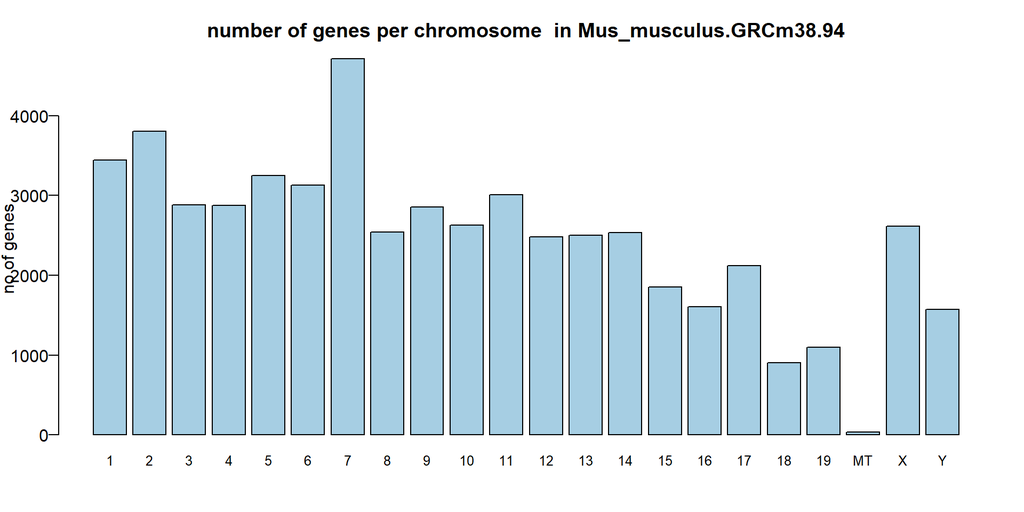

#### Randomly select 200 genes from each chromosome.

Check they all look right

|  | gene_id | gene_name | chromosome | start | end | strand | biotype | biotype_family | length | GC_content | no_of_transcripts |
| --- | --- | --- | --- | --- | --- | --- | --- | --- | --- | --- | --- |
| 13975 | ENSMUSG00000064850 | Gm23443 | 4 | 93545150 | 93545277 | - | snoRNA | NA | 127 | 0.528 | 1 |
| 13673 | ENSMUSG00000039196 | Orm1 | 4 | 63344560 | 63348163 | + | protein_coding | NA | 3603 | 0.501 | 1 |
| 14538 | ENSMUSG00000028631 | Kcnq4 | 4 | 120696138 | 120748612 | - | protein_coding | NA | 52474 | 0.532 | 2 |
| 15220 | ENSMUSG00000084351 | Gm13085 | 4 | 143663143 | 143663787 | - | processed_pseudogene | NA | 644 | 0.475 | 1 |
| 14041 | ENSMUSG00000083644 | Gm12787 | 4 | 98268083 | 98268575 | - | processed_pseudogene | NA | 492 | 0.474 | 1 |
| 14731 | ENSMUSG00000028804 | Csmd2 | 4 | 127987857 | 128567656 | + | protein_coding | NA | 579799 | 0.480 | 6 |

|  | gene_id | gene_name | chromosome | start | end | strand | biotype | biotype_family | length | GC_content | no_of_transcripts |
| --- | --- | --- | --- | --- | --- | --- | --- | --- | --- | --- | --- |
| 47694.2 | ENSMUSG00000048939 | Atp13a5 | 16 | 29231851 | 29378732 | - | protein_coding | NA | 146881 | 0.414 | 4 |
| 47448 | ENSMUSG00000080364 | Gm25777 | 16 | 18240717 | 18240842 | - | snoRNA | NA | 125 | 0.560 | 1 |
| 48552 | ENSMUSG00000093256 | Gm22933 | 16 | 90953795 | 90953868 | + | miRNA | NA | 73 | 0.521 | 1 |
| 48358 | ENSMUSG00000102344 | 9430053O09Rik | 16 | 77419251 | 77421820 | - | TEC | NA | 2569 | 0.376 | 1 |
| 48330 | ENSMUSG00000032940 | Rbm11 | 16 | 75592844 | 75602829 | + | protein_coding | NA | 9985 | 0.397 | 3 |
| 48680 | ENSMUSG00000022914 | Brwd1 | 16 | 95992092 | 96082526 | - | protein_coding | NA | 90434 | 0.429 | 16 |

|  | gene_id | gene_name | chromosome | start | end | strand | biotype | biotype_family | length | GC_content | no_of_transcripts |
| --- | --- | --- | --- | --- | --- | --- | --- | --- | --- | --- | --- |
| 8512 | ENSMUSG00000083444 | Gm14768 | X | 80362549 | 80363233 | + | processed_pseudogene | NA | 684 | 0.374 | 1 |
| 7311 | ENSMUSG00000073295 | Nudt11 | X | 6047453 | 6055110 | + | protein_coding | NA | 7657 | 0.419 | 1 |
| 7846 | ENSMUSG00000051361 | 6030498E09Rik | X | 38772671 | 38962686 | + | protein_coding | NA | 190015 | 0.392 | 2 |
| 7949 | ENSMUSG00000082192 | Gm14719 | X | 49660960 | 49661299 | + | processed_pseudogene | NA | 339 | 0.622 | 1 |
| 8181 | ENSMUSG00000083570 | Gm14671 | X | 66024044 | 66024305 | + | processed_pseudogene | NA | 261 | 0.448 | 1 |
| 9819 | ENSMUSG00000082019 | Gm15231 | X | 166935469 | 166935915 | + | processed_pseudogene | NA | 446 | 0.397 | 1 |

### GO overrepresentation analysis

Run the gene lists through a GO overrepresentation analysis.

We don’t want to run the GO analysis each time the document is knitted as it takes too long. The code was run once and the data saved as an .rda object that can be quickly loaded in to the R session.

See how many significant categories were returned.

Remove null lists from chr_results

The number of gene sets that returned significant results from the GO overrepresentation analysis

```
##   1   2   3   4   5   6   7   8   9  10  11  12  13  14  15  16  17  18
##   2  61  12  19   3  46  21   5  16   3  61  87  33   2   5   4  51 100
##  19  MT   X   Y
##  99 100   8  67
```

The box plots show the number of categories returned from each gene list. The null results have been removed.

The beanplot won’t work “Error in bw.SJ(x, method =”dpi“) : sample is too sparse to find TD”

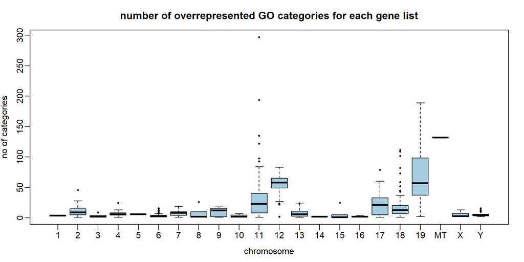

### The number of times that a GO category appears in the 100 tests

### Determining thresholds for the number of times a category appears.

If a GO category is only found in one of the 100 tests, we do not want to flag that up as a suspect category, but how many times should it appear for us to include it in the suspect list?

Set a cut-off for the minimum number of times a category must appear in the 100 tests.

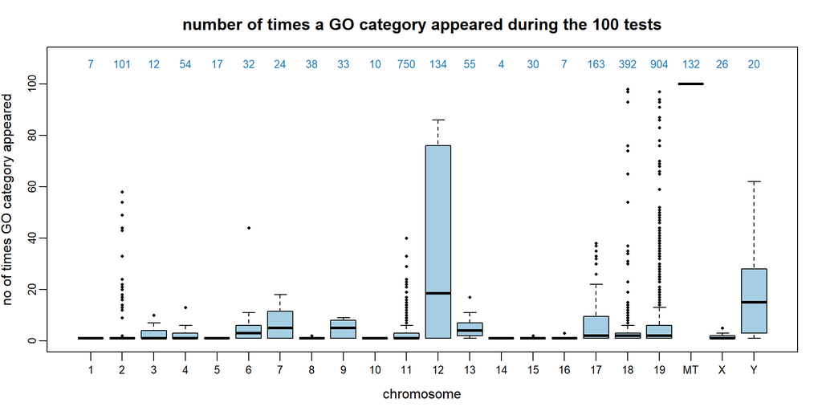

Replot just showing the data for categories that appeared >= 15

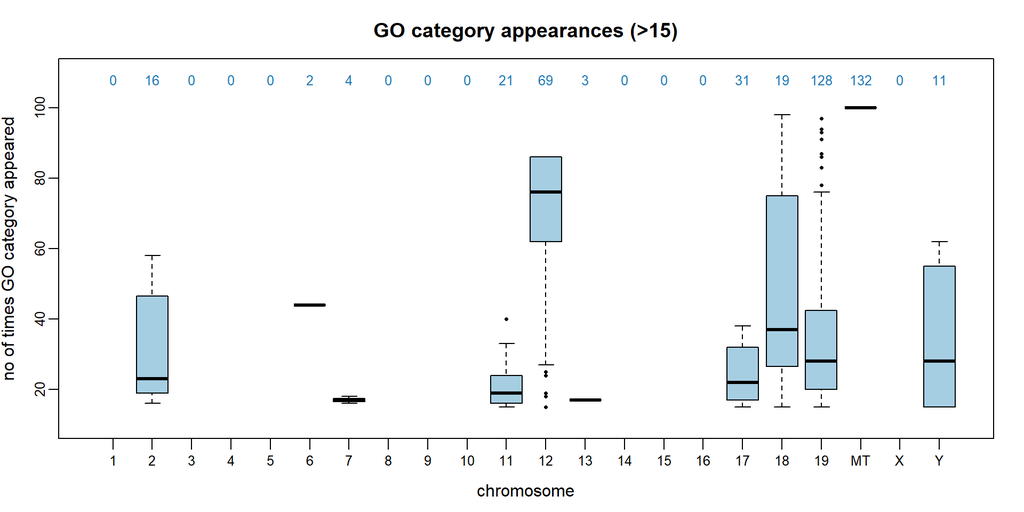

Now we could do with some stats to pick a cutoff for the number of times a category appears. Let’s just select an arbitrary value…

Create a dataset that contains these suspect set of categories

```
##   1  10  11  12  13  14  15  16  17  18  19   2   3   4   5   6   7   8
##   0   0  21  69   3   0   0   0  31  19 128  16   0   0   0   2   4   0
##   9  MT   X   Y
##   0 132   0  11
```

We don’t need empty files so remove categories with no results.

```
##  11  12  13  17  18  19   2   6   7  MT   Y
##  21  69   3  31  19 128  16   2   4 132  11
```